# notes

# Summary

```
## 'data.frame':    1106 obs. of  25 variables:
##  $ q0.1_time             : Date, format: "2017-04-18" "2017-04-18" ...
##  $ q1.1_usefb            : Ord.factor w/ 4 levels "1"<"2"<"3"<"4": 4 1 4 4 4 3 1 4 4 4 ...
##  $ q1.2_useig            : Ord.factor w/ 4 levels "1"<"2"<"3"<"4": 1 2 3 2 1 1 1 1 3 1 ...
##  $ q1.3_usesc            : Ord.factor w/ 4 levels "1"<"2"<"3"<"4": 4 4 3 2 3 1 4 2 2 2 ...
##  $ q2.1_nocare           : Ord.factor w/ 4 levels "1"<"2"<"3"<"4": 1 2 1 2 3 1 2 2 1 1 ...
##  $ q3.1_gender           : Factor w/ 2 levels "kvinde","mand": 1 2 1 2 2 1 2 1 1 2 ...
##  $ q4.1_age              : num  17 17 18 16 17 18 19 18 18 17 ...
##  $ q5.1_digedu           : Factor w/ 2 levels "ja","nej": 2 1 2 1 2 1 2 2 1 2 ...
##  $ q6.1_school           : Factor w/ 15 levels "borupgaard","egedal",..: 12 8 12 8 12 8 12 12 12 12 ...
##  $ q7.1_editedprivacy    : Ord.factor w/ 4 levels "1"<"2"<"3"<"4": 4 2 3 3 2 4 3 3 4 4 ...
##  $ q8.1_freqpost         : Ord.factor w/ 7 levels "1"<"2"<"3"<"4"<..: 2 1 1 5 2 2 1 1 5 1 ...
##  $ q8.2_freqsend         : Ord.factor w/ 7 levels "1"<"2"<"3"<"4"<..: 7 1 6 6 4 4 4 7 6 6 ...
##  $ q8.3_freqread         : Ord.factor w/ 7 levels "1"<"2"<"3"<"4"<..: 6 6 6 6 2 4 6 7 6 6 ...
##  $ q9.1_seecontent       : Ord.factor w/ 4 levels "1"<"2"<"3"<"4": 3 1 2 3 2 3 2 2 2 1 ...
##  $ q10.1_understand      : Ord.factor w/ 4 levels "1"<"2"<"3"<"4": 2 4 2 3 1 3 2 2 2 3 ...
##  $ q11.1_seemypost       : Ord.factor w/ 4 levels "1"<"2"<"3"<"4": 2 1 3 3 3 3 1 2 2 2 ...
##  $ q12.1_controlseemypost: Ord.factor w/ 4 levels "1"<"2"<"3"<"4": 3 1 3 3 3 3 1 2 2 3 ...
##  $ q13.1_audience        : Ord.factor w/ 4 levels "1"<"2"<"3"<"4": 2 1 2 3 2 3 1 2 1 3 ...
##  $ q14.1_trustconn       : Ord.factor w/ 4 levels "1"<"2"<"3"<"4": 3 1 3 3 2 3 1 2 2 3 ...
##  $ q15.1_trustsell       : Ord.factor w/ 4 levels "1"<"2"<"3"<"4": 3 1 1 2 1 2 1 2 3 2 ...
##  $ q16.1_trustpriv       : Ord.factor w/ 4 levels "1"<"2"<"3"<"4": 3 1 3 3 1 3 3 3 3 3 ...
##  $ q17.1_targetme        : Ord.factor w/ 4 levels "1"<"2"<"3"<"4": 3 1 2 3 1 3 3 2 3 2 ...
##  $ q18.1_targetfr        : Ord.factor w/ 4 levels "1"<"2"<"3"<"4": 2 1 2 2 1 2 3 2 3 1 ...
##  $ q19.1_comfortsell     : Ord.factor w/ 4 levels "1"<"2"<"3"<"4": 2 1 2 2 2 2 3 1 1 1 ...
##  $ platform              : Factor w/ 3 levels "fb","ig","sc": 1 1 1 1 1 1 1 1 1 1 ...
## NULL
```

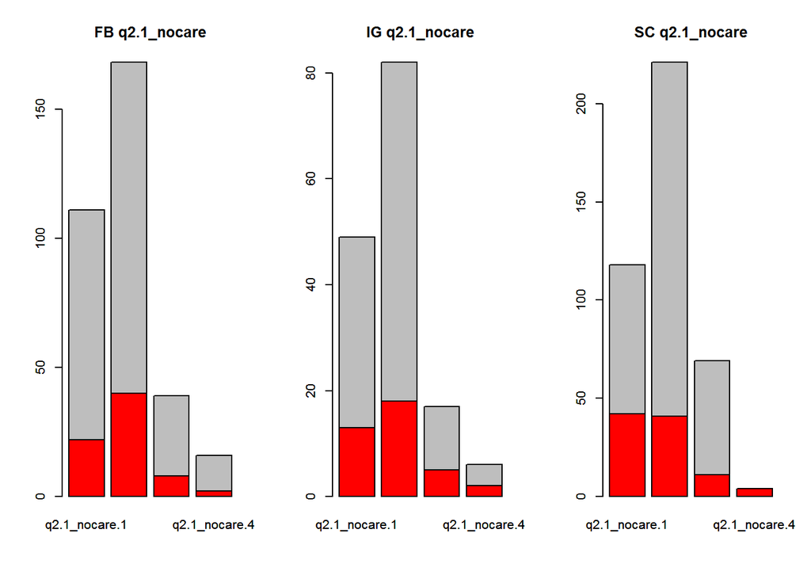

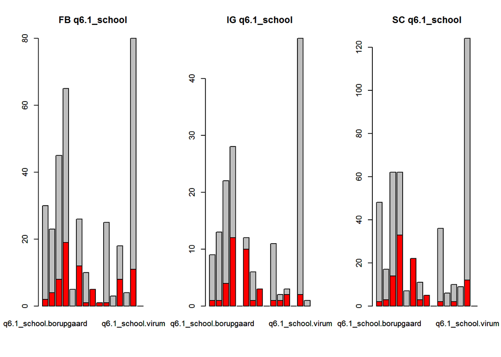

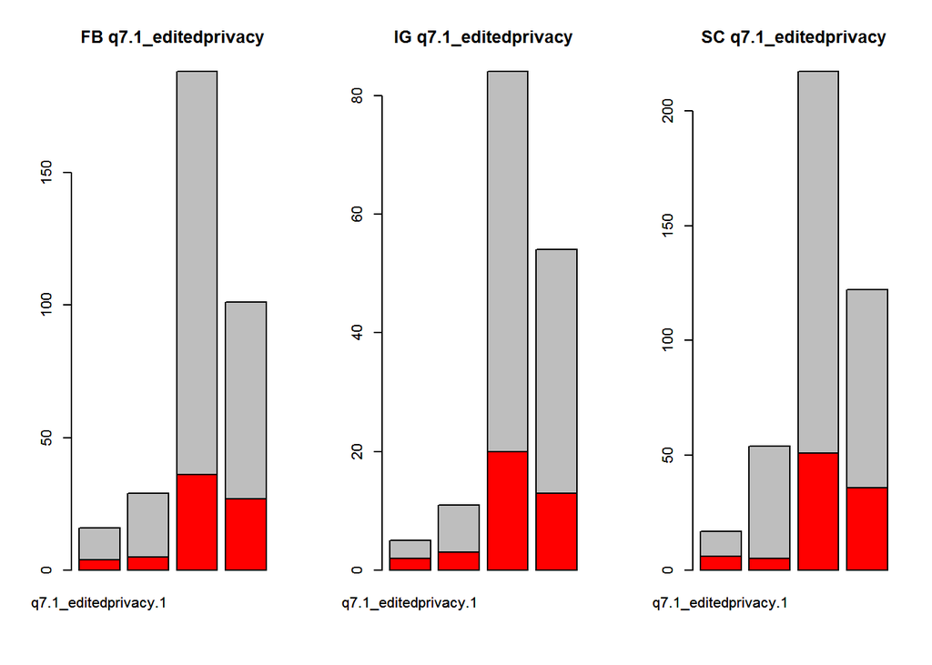

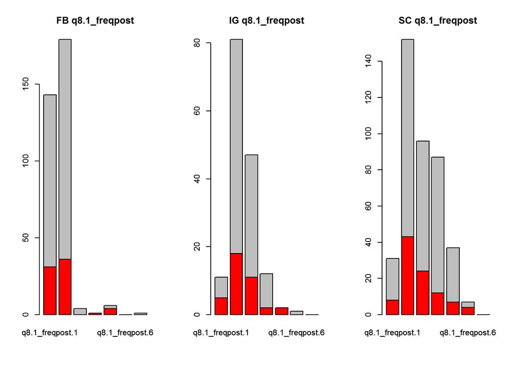

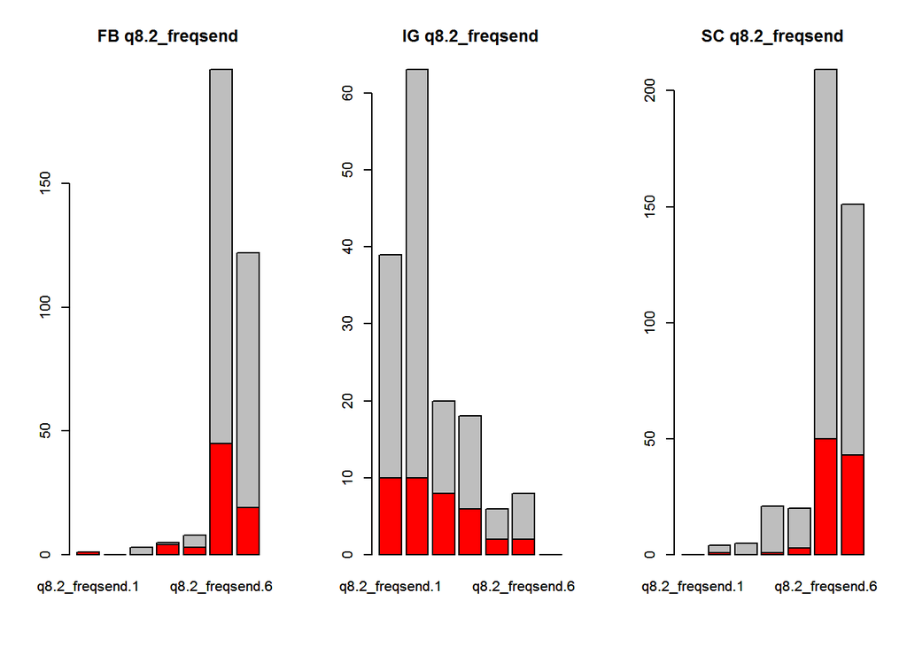

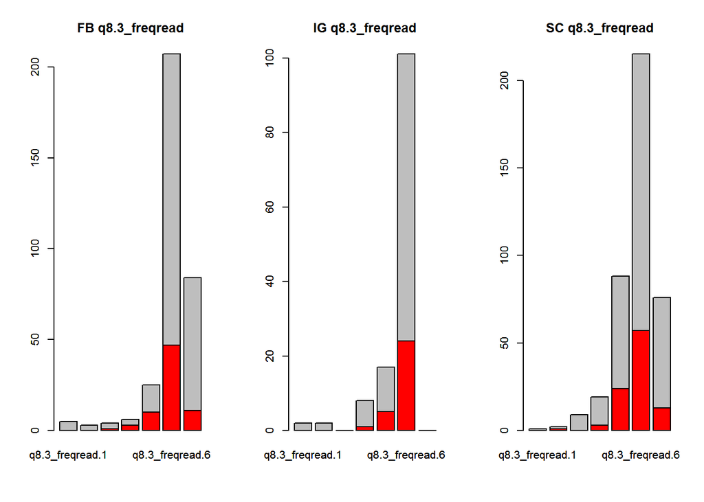

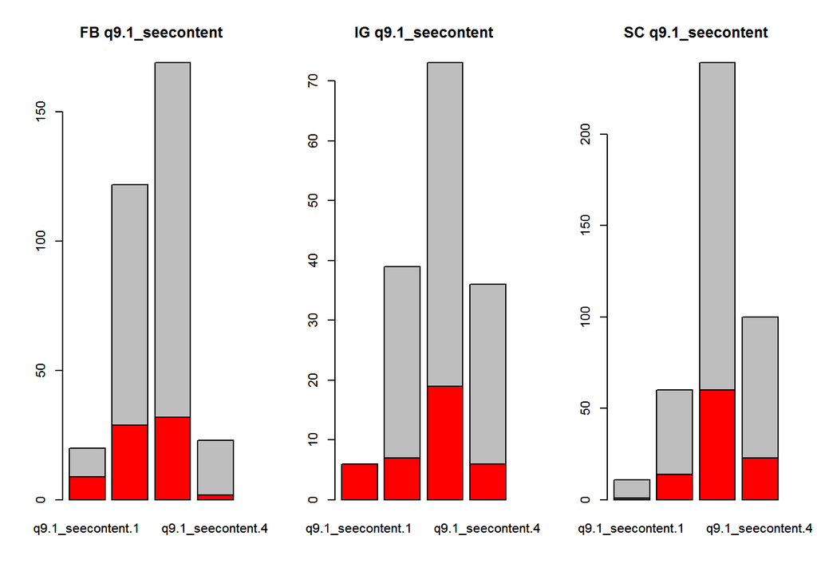

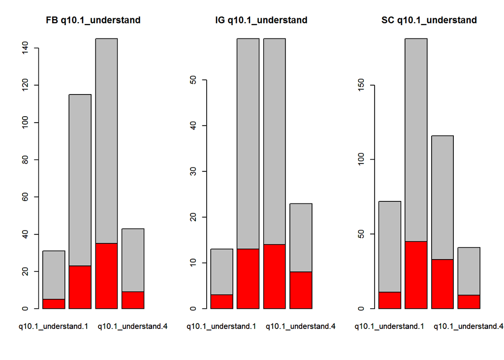

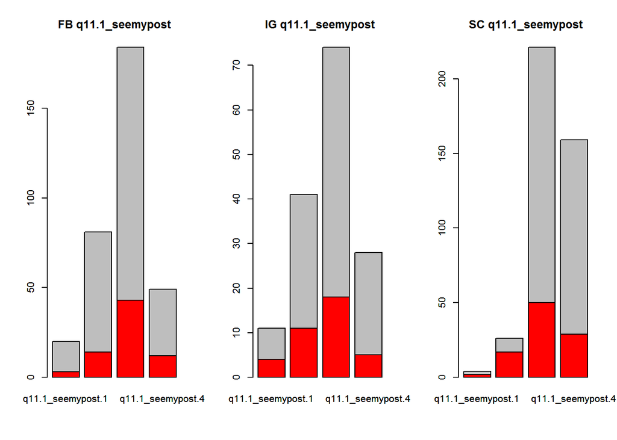

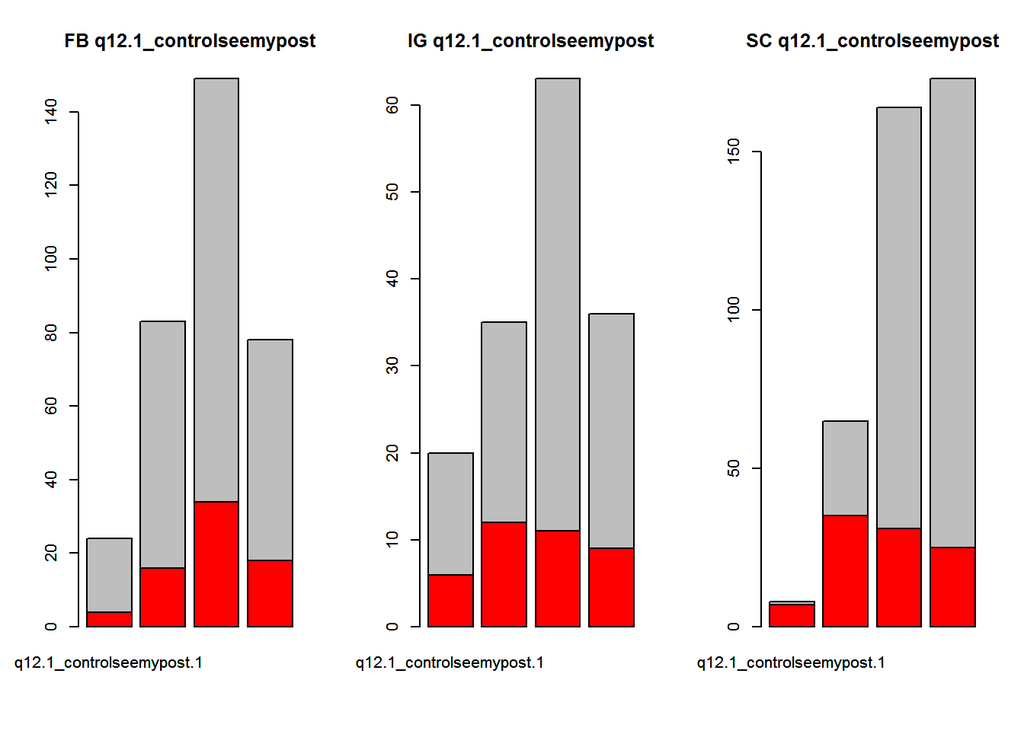

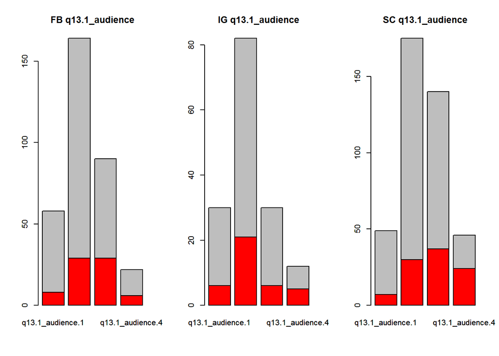

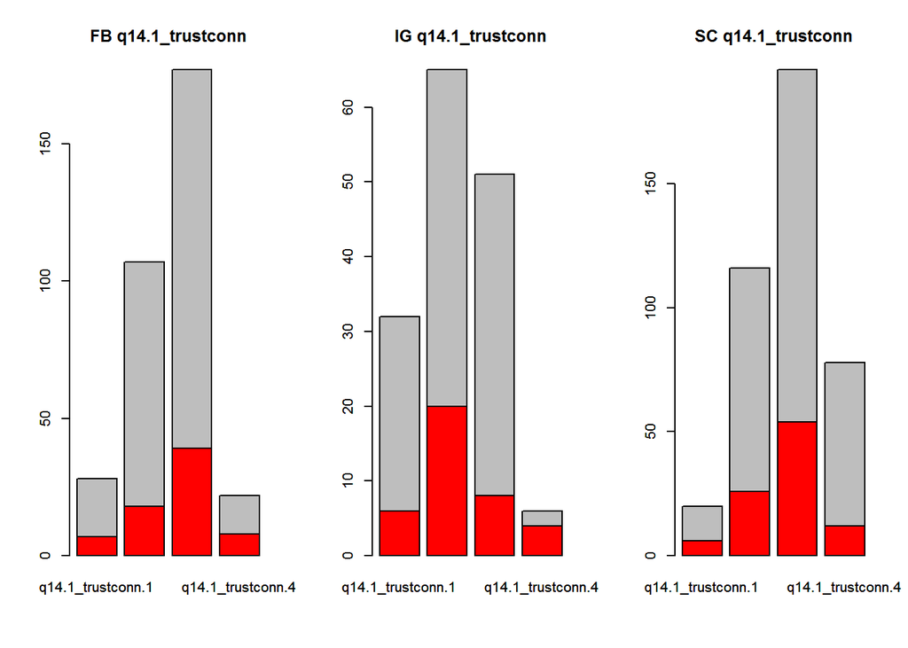

[5 more figures not shown]

# Chisq p-values (Hypotheses for M and A)

- Null hypothesis - independent
- Alternative hypothesis - they are NOT independent
- high p-value = there is no relation
- low p-value = there is a relation

Common treshold is 0.05 (or 5%) and I suggest you stick with it. So if a p-value is below 5% there is not enough evidence to support the null hypothesis that x and y are independent. You have to accept that x and y are dependent.

If the p-value is above 5% there is not enough evidence to disprove that x and y are independent. You have to accept that they are independent.

## H4

### H4a (table of counts)

The table of frequencies of use of different platforms. Based on the entire, combined, data set [Fb,Ig,Sc].

|  | 1 | 2 | 3 | 4 |
| --- | --- | --- | --- | --- |
| q1.1_usefb | 18 | 56 | 129 | 903 |
| q1.2_useig | 230 | 227 | 285 | 364 |
| q1.3_usesc | 44 | 76 | 196 | 790 |

### H4b (Chisq p-values)

Chisq tests of the type Platform_use_freq ~ q8.1, q8.2, q8.3. #PlatformSpecific, #BeforeAfter

Facebook

|  | q8.1_freqpost | q8.2_freqsend | q8.3_freqread |
| --- | --- | --- | --- |
| noEdu | 0.999 | 0 | 0.000 |
| Edu | 0.943 | 0 | 0.648 |

Instagram

|  | q8.1_freqpost | q8.2_freqsend | q8.3_freqread |
| --- | --- | --- | --- |
| noEdu | 0.000 | 0.030 | 0.000 |
| Edu | 0.013 | 0.671 | 0.664 |

Snapchat

|  | q8.1_freqpost | q8.2_freqsend | q8.3_freqread |
| --- | --- | --- | --- |
| noEdu | 0.013 | 0 | 0.000 |
| Edu | 0.539 | 0 | 0.319 |

## H5 (Chisq p-values)

Only fb_q9 and ig_q9 are answered correctly with disagreement. The rest of the questions sc_q9, 10, 11 and 12 for the three platforms are answered correctly with agreement.

Facebook

|  | q9binary vs q10binary | q11binary vs q12binary |
| --- | --- | --- |
| noEdu | 0.006 | 0 |
| Edu | 0.187 | 0 |

Instagram

|  | q9binary vs q10binary | q11binary vs q12binary |
| --- | --- | --- |
| noEdu | 0.113 | 0.001 |
| Edu | 0.985 | 0.354 |

Snapchat

|  | q9binary vs q10binary | q11binary vs q12binary |
| --- | --- | --- |
| noEdu | 0.208 | 0.117 |
| Edu | 0.599 | 0.024 |

## H0

## H0a (Chisq p-values)

Caring about privacy settings vs eiditing privacy settings. Taken on the entire, combined, data set [fb,ig,sc]

| before | 0 |
| --- | --- |
| after | 0 |

### H0b (correlation)

| before | -0.364 |
| --- | --- |
| after | -0.493 |

## HX

### HXa (table of counts)

The row labels in the tables below are as well 1 to 4. Q15 vs Q16

Facebook before. q15 rows, q16 cols

| 1 | 2 | 3 | 4 |
| --- | --- | --- | --- |
| 16 | 24 | 46 | 11 |
| 0 | 24 | 91 | 13 |
| 0 | 6 | 63 | 17 |
| 0 | 0 | 9 | 14 |

Facebook after q15 rows, q16 cols

| 1 | 2 | 3 | 4 |
| --- | --- | --- | --- |
| 6 | 5 | 8 | 1 |
| 0 | 6 | 15 | 6 |
| 0 | 1 | 11 | 7 |
| 0 | 0 | 4 | 2 |

Instagram before. q15 rows, q16 cols

| 1 | 2 | 3 | 4 |
| --- | --- | --- | --- |
| 1 | 2 | 13 | 2 |
| 1 | 9 | 37 | 4 |
| 1 | 2 | 57 | 8 |
| 0 | 0 | 8 | 9 |

Instagram after q15 rows, q16 cols

| 1 | 2 | 3 | 4 |
| --- | --- | --- | --- |
| 1 | 4 | 5 | 1 |
| 0 | 6 | 8 | 4 |
| 0 | 0 | 4 | 4 |
| 0 | 0 | 0 | 1 |

Snapchat before. q15 rows, q16 cols

| 1 | 2 | 3 | 4 |
| --- | --- | --- | --- |
| 9 | 14 | 21 | 4 |
| 1 | 32 | 80 | 9 |
| 1 | 11 | 146 | 21 |
| 0 | 0 | 25 | 36 |

Snapchat after q15 rows, q16 cols

| 1 | 2 | 3 | 4 |
| --- | --- | --- | --- |
| 8 | 6 | 11 | 1 |
| 2 | 21 | 21 | 1 |
| 0 | 1 | 19 | 3 |
| 0 | 0 | 3 | 1 |

### HXb (Chisq p-values)

Platform specific and before/after q15 vs q17, q18 and q19

Facebook

|  | q17.1_targetme | q18.1_targetfr | q19.1_comfortsell |
| --- | --- | --- | --- |
| noEdu | 0.354 | 0.007 | 0.065 |
| Edu | 0.198 | 0.350 | 0.228 |

Instagram

|  | q17.1_targetme | q18.1_targetfr | q19.1_comfortsell |
| --- | --- | --- | --- |
| noEdu | 0.019 | 0.000 | 0.002 |
| Edu | 0.847 | 0.652 | 0.882 |

Snapchat

|  | q17.1_targetme | q18.1_targetfr | q19.1_comfortsell |
| --- | --- | --- | --- |
| noEdu | 0.013 | 0.024 | 0.001 |
| Edu | 0.653 | 0.409 | 0.041 |

## H6, Q13 vs Q14

|  | fb | ig | sc |
| --- | --- | --- | --- |
| noEdu | 0.000 | 0.000 | 0.000 |
| Edu | 0.265 | 0.015 | 0.006 |

## H1, 10-05-2017, q15 vs q16

# Chisq

|  | fb | ig | sc |
| --- | --- | --- | --- |
| noEdu | 0.000 | 0.000 | 0 |
| Edu | 0.003 | 0.262 | 0 |

# Correlation

|  | fb | ig | sc |
| --- | --- | --- | --- |
| noEdu | 0.406 | 0.303 | 0.490 |
| Edu | 0.486 | 0.467 | 0.451 |

## H2, 10-05-2017, q15 vs q17

# Chisq

|  | fb | ig | sc |
| --- | --- | --- | --- |
| noEdu | 0.354 | 0.019 | 0.013 |
| Edu | 0.198 | 0.847 | 0.653 |

# Correlation

|  | fb | ig | sc |
| --- | --- | --- | --- |
| noEdu | 0.075 | 0.002 | 0.105 |
| Edu | 0.131 | -0.171 | 0.007 |

## H3, 10-05-2017, q15 vs q18

# Chisq

|  | fb | ig | sc |
| --- | --- | --- | --- |
| noEdu | 0.007 | 0.000 | 0.024 |
| Edu | 0.350 | 0.652 | 0.409 |

# Correlation

|  | fb | ig | sc |
| --- | --- | --- | --- |
| noEdu | 0.095 | 0.171 | 0.144 |
| Edu | 0.047 | -0.293 | 0.012 |

## H4, 10-05-2017, q15 vs q19

# Chisq

|  | fb | ig | sc |
| --- | --- | --- | --- |
| noEdu | 0.065 | 0.002 | 0.001 |
| Edu | 0.228 | 0.882 | 0.041 |

# Correlation

|  | fb | ig | sc |
| --- | --- | --- | --- |
| noEdu | -0.039 | -0.033 | -0.029 |
| Edu | -0.116 | -0.164 | -0.231 |